# 32_keras_regression

Bakro

1/3/2022

## Basic Regression

```r
library(keras)
library(tfdatasets)
library(tensorflow)
```

## The dataset

**Boston Housing Prices**

```r
boston_housing <- dataset_boston_housing()
```

```
## Loaded Tensorflow version 2.7.0
```

```r
c(train_data, train_labels) %<-% boston_housing$train
c(test_data, test_labels) %<-% boston_housing$test
```

```r
paste0("Training entries: ", length(train_data), ", labels: ", length(train_labels))
```

```
## [1] "Training entries: 5252, labels: 404"
```

The dataset contains 13 different features:

- Per capita crime rate.
- The proportion of residential land zoned for lots over 25,000 square feet.
- The proportion of non-retail business acres per town.
- Charles River dummy variable (= 1 if tract bounds river; 0 otherwise).
- Nitric oxides concentration (parts per 10 million).
- The average number of rooms per dwelling.
- The proportion of owner-occupied units built before 1940.
- Weighted distances to five Boston employment centers.
- Index of accessibility to radial highways.
- Full-value property-tax rate per $10,000.
- Pupil-teacher ratio by town.
- 1000 * (Bk - 0.63) ** 2 where Bk is the proportion of Black people by town.
- Percentage lower status of the population.

```r
train_data[1, ] # Display sample features, notice the different scales
```

```
##  [1]   1.23247   0.00000   8.14000   0.00000   0.53800   6.14200  91.70000
##  [8]   3.97690   4.00000 307.00000  21.00000 396.90000  18.72000
```

```r
library(dplyr)

column_names <- c('CRIM', 'ZN', 'INDUS', 'CHAS', 'NOX', 'RM', 'AGE',
                  'DIS', 'RAD', 'TAX', 'PTRATIO', 'B', 'LSTAT')

train_df <- train_data %>%
  as_tibble(.name_repair = "minimal") %>%
  setNames(column_names) %>%
  mutate(label = train_labels)

test_df <- test_data %>%
  as_tibble(.name_repair = "minimal") %>%
  setNames(column_names) %>%
  mutate(label = test_labels)
```

### LABELS

The labels are the house prices in thousands of dollars. (You may notice the mid-1970s prices.)

```r
train_labels[1:10] # Display first 10 entries
```

```
##  [1] 15.2 42.3 50.0 21.1 17.7 18.5 11.3 15.6 15.6 14.4
```

### Normalize features

recommended to normalize features that use different scales and ranges. Although the model might converge without feature normalization, it makes training more difficult, and it makes the resulting model more dependent on the choice of units used in the input.

```r
spec <- feature_spec(dataset = train_df, label ~ . ) %>%
  step_numeric_column(all_numeric(), normalizer_fn = scaler_standard()) %>%
  fit()

spec
```

```
## -- Feature Spec ----------------------------------------------------------------
## A feature_spec with 13 steps.
## Fitted: TRUE
## -- Steps -----------------------------------------------------------------------
## The feature_spec has 1 dense features.
## StepNumericColumn: CRIM, ZN, INDUS, CHAS, NOX, RM, AGE, DIS, RAD, TAX, PTRATIO, B, LSTAT
## -- Dense features --------------------------------------------------------------
```

```r
# The spec created with tfdatasets can be used together with layer_dense_features to perform pre-processing directly in the TensorFlow graph.
#
```

```r
# We can take a look at the output of a dense-features layer created by this spec
layer <- layer_dense_features(
  feature_columns = dense_features(spec),
  dtype = tf$float32
)

#layer(train_df)
```

### Create the model

```r
input <- layer_input_from_dataset(train_df %>% select(-label))

output <- input %>%
  layer_dense_features(dense_features(spec)) %>%
  layer_dense(units = 64, activation = "relu") %>%
  layer_dense(units = 64, activation = "relu") %>%
  layer_dense(units = 1)

model <- keras_model(input, output)

summary(model)
```

```
## Model: "model"
## ________________________________________________________________________________
##  Layer (type)             Output Shape      Param #  Connected to
## ================================================================================
##  AGE (InputLayer)         [(None,)]         0        []
##
##  B (InputLayer)           [(None,)]         0        []
##
##  CHAS (InputLayer)        [(None,)]         0        []
##
##  CRIM (InputLayer)        [(None,)]         0        []
##
##  DIS (InputLayer)         [(None,)]         0        []
##
##  INDUS (InputLayer)       [(None,)]         0        []
##
##  LSTAT (InputLayer)       [(None,)]         0        []
##
##  NOX (InputLayer)         [(None,)]         0        []
##
##  PTRATIO (InputLayer)     [(None,)]         0        []
##
##  RAD (InputLayer)         [(None,)]         0        []
##
##  RM (InputLayer)          [(None,)]         0        []
##
##  TAX (InputLayer)         [(None,)]         0        []
##
##  ZN (InputLayer)          [(None,)]         0        []
##
##  dense_features_1 (DenseF  (None, 13)       0        ['AGE[0][0]',
##  eatures)                                             'B[0][0]',
##                                                       'CHAS[0][0]',
##                                                       'CRIM[0][0]',
##                                                       'DIS[0][0]',
##                                                       'INDUS[0][0]',
##                                                       'LSTAT[0][0]',
##                                                       'NOX[0][0]',
##                                                       'PTRATIO[0][0]',
##                                                       'RAD[0][0]',
##                                                       'RM[0][0]',
##                                                       'TAX[0][0]',
##                                                       'ZN[0][0]']
##
##  dense_2 (Dense)          (None, 64)        896      ['dense_features_1[0][0]']
##
##  dense_1 (Dense)          (None, 64)        4160     ['dense_2[0][0]']
##
##  dense (Dense)            (None, 1)         65       ['dense_1[0][0]']
##
## ================================================================================
## Total params: 5,121
## Trainable params: 5,121
## Non-trainable params: 0
## ________________________________________________________________________________
```

```r
model %>%
  compile(
    loss = "mse",
    optimizer = optimizer_rmsprop(),
    metrics = list("mean_absolute_error")
  )
```

We will wrap the model building code into a function in order to be able to reuse it for different experiments. Remember that Keras `fit` modifies the model in-place.

```r
build_model <- function() {
  input <- layer_input_from_dataset(train_df %>% select(-label))

  output <- input %>%
    layer_dense_features(dense_features(spec)) %>%
    layer_dense(units = 64, activation = "relu") %>%
    layer_dense(units = 64, activation = "relu") %>%
    layer_dense(units = 1)

  model <- keras_model(input, output)

  model %>%
    compile(
      loss = "mse",
      optimizer = optimizer_rmsprop(),
      metrics = list("mean_absolute_error")
    )

  model
}
```

```r
# Display training progress by printing a single dot for each completed epoch.
print_dot_callback <- callback_lambda(
  on_epoch_end = function(epoch, logs) {
    if (epoch %% 80 == 0) cat("\n")
    cat(".")
  }
)

model <- build_model()

history <- model %>% fit(
  x = train_df %>% select(-label),
  y = train_df$label,
  epochs = 500,
  validation_split = 0.2,
  verbose = 0,
  callbacks = list(print_dot_callback)
)
```

```
##
## ................................................................................
## ................................................................................
## ................................................................................
## ................................................................................
## ................................................................................
## ................................................................................
## ....................
```

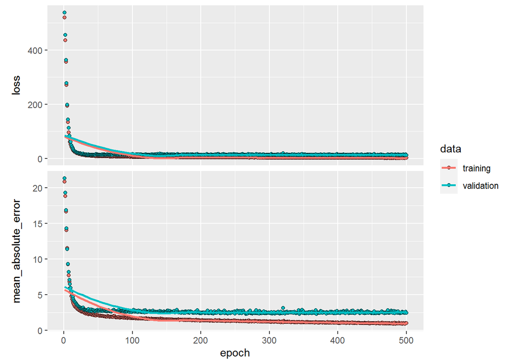

```r
library(ggplot2)
plot(history)
```

his graph shows little improvement in the model after about 200 epochs. Let’s update the `fit` method to automatically stop training when the validation score doesn’t improve. We’ll use a [callback](https://keras.rstudio.com/reference/callback_early_stopping.html) that tests a training condition for every epoch. If a set amount of epochs elapses without showing improvement, it automatically stops the training.

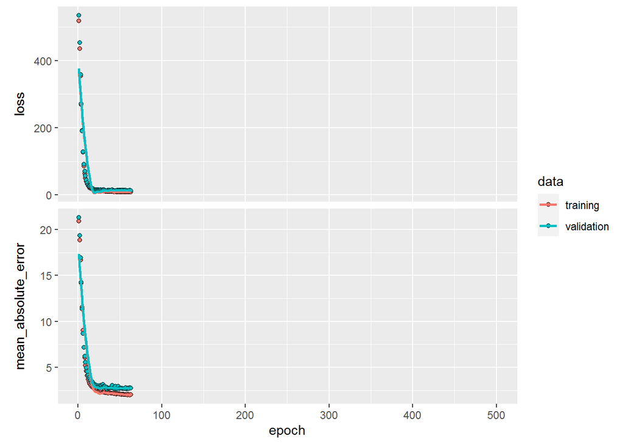

```r
# The patience parameter is the amount of epochs to check for improvement.
early_stop <- callback_early_stopping(monitor = "val_loss", patience = 20)

model <- build_model()

history <- model %>% fit(
  x = train_df %>% select(-label),
  y = train_df$label,
  epochs = 500,
  validation_split = 0.2,
  verbose = 0,
  callbacks = list(early_stop)
)

plot(history)
```

```r
# The graph shows the average error is about $2,500 dollars. Is this good? Well, $2,500 is not an insignificant amount when some of the labels are only $15,000.
#
# Let’s see how did the model performs on the test set:
```

### Predict

```r
test_predictions <- model %>% predict(test_df %>% select(-label))
test_predictions[ , 1]
```

```
##   [1]  7.626901 17.088373 21.294844 33.554729 25.089485 19.016235 26.874468
##   [8] 21.920872 18.989189 22.154789 17.379286 16.737659 15.769759 40.955544
##  [15] 19.349234 18.792852 26.287176 21.851717 18.837929 33.908997 10.650352
##  [22] 15.479531 20.470781 13.756508 21.016186 24.780104 31.163185 28.033064
##  [29]  9.768211 20.535521 18.577944 14.300484 33.446278 24.561575 17.407202
##  [36]  7.346484 15.373009 17.284462 19.527073 26.766691 30.085066 27.861250
##  [43] 13.392559 39.581604 29.209623 24.592489 26.205343 15.983734 23.066088
##  [50] 21.790047 34.737808 19.526167 10.728026 15.775757 35.962460 27.570692
##  [57] 11.876560 47.288734 35.466370 23.650501 24.432913 17.081160 14.764398
##  [64] 17.565741 22.576696 22.872721 12.742924 22.908434 14.253733  6.559023
##  [71] 33.913502 28.395693 25.577522 14.759851 25.787157 17.864214 19.411375
##  [78] 23.037247 35.503792  9.594757 19.670893 37.903137 14.499865 13.091137
##  [85] 17.152964 17.556925 20.057770 21.706442 21.663023 30.352446 19.642174
##  [92] 18.881025 25.626076 38.856590 36.037956 18.910187 36.069580 51.532089
##  [99] 26.365934 45.599701 33.090488 19.684813
```

### Conclusion

This notebook introduced a few techniques to handle a regression problem.

- Mean Squared Error (MSE) is a common loss function used for regression problems (different than classification problems).
- Similarly, evaluation metrics used for regression differ from classification. A common regression metric is Mean Absolute Error (MAE).
- When input data features have values with different ranges, each feature should be scaled independently.
- If there is not much training data, prefer a small network with few hidden layers to avoid overfitting.
- Early stopping is a useful technique to prevent overfitting.